# Automated report writing using exploratory analysis of Movies data in R

## Visualizing catagorical variables

Using the ggplot() function from the ggplot2 package, the bargraph for the categorical variables were produced. With the help of the pipe operator (`%>%`) from the dplyr package, the variable was initially chosen and summarised to obtain counts for each level of the variable.

### Visualizing counts of GENRE

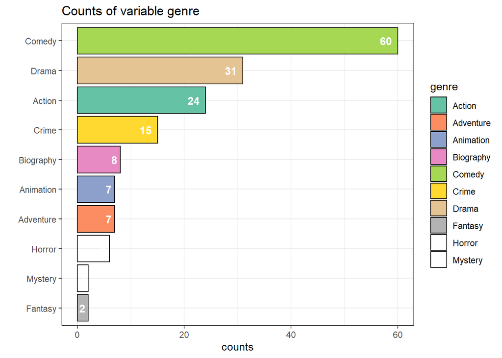

```r
df %>%
          select_if(is.character) %>%
          group_by(genre) %>%
          summarise(counts = n()) %>%
          na.omit() %>%
          ggplot(mapping = aes(x = reorder(genre, counts),
                               y = counts,
                               fill = genre)) +
                    geom_bar(stat = "identity",
                             color = "black",
                             position = position_dodge(width = 0.9)) +
          coord_flip() +
          geom_text(aes(label = counts), hjust = 1.5,vjust = 0.5,
                    colour = "white", fontface = "bold",
                    position = position_dodge(width = 0.9)) +
          labs(x = "", title = "Counts of variable genre") +
          scale_fill_brewer(palette = "Set2") +
          theme_bw()
```

Maximum number of movies (60) in this data set belongs to category Comedy. The total number of movies that belong to type Action were 24. However, the least number of movies were recorded in category Fantasy with counts of 2.

### Visualizing counts of rating

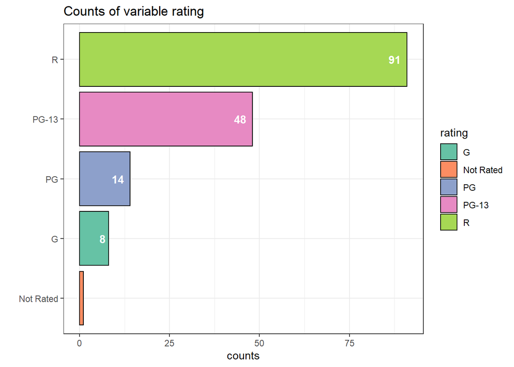

```r
df %>%
          select_if(is.character) %>%
          group_by(rating) %>%
          summarise(counts = n()) %>%
          na.omit() %>%
          ggplot(mapping = aes(x = reorder(rating, counts),
                               y = counts,
                               fill = rating)) +
                    geom_bar(stat = "identity",
                             color = "black",
                             position = position_dodge(width = 0.9)) +
          coord_flip() +
          geom_text(aes(label = counts), hjust = 1.5,vjust = 0.5,
                    colour = "white", fontface = "bold",
                    position = position_dodge(width = 0.9)) +
          labs(x = "", title = "Counts of variable rating") +
          scale_fill_brewer(palette = "Set2") +
          theme_bw()
```

Maximum number of ratings (91) in this data set belongs to category R followed by PG-13 with rating of 48. However, the least rating was received by the category Not Rated with counts of 1.

### Visualizing counts of countries

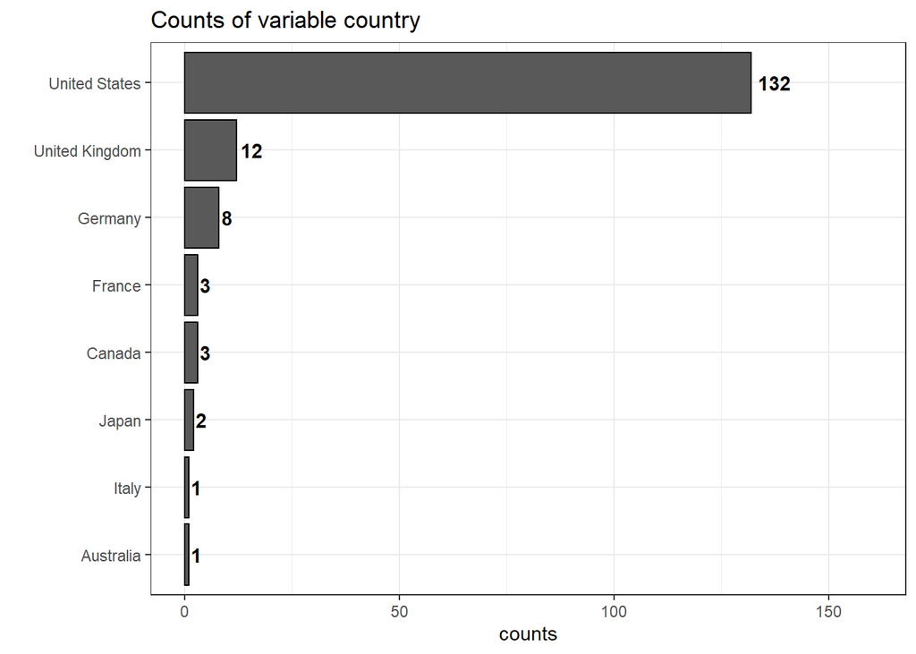

```r
df %>%
          select_if(is.character) %>%
          group_by(country) %>%
          summarise(counts = n()) %>%
          na.omit() %>%
          ggplot(mapping = aes(x = reorder(country, counts),
                               y = counts)) +
                    geom_bar(stat = "identity",
                             color = "black",
                             position = position_dodge(width = 0.9)) +
          ylim(0, 160) +
          coord_flip() +
          geom_text(aes(label = counts), hjust = -0.2,vjust = 0.5,
                    colour = "black", fontface = "bold",
                    position = position_dodge(width = 0.9)) +
          labs(x = "", title = "Counts of variable country") +
          theme_bw()
```

The above plot showed that the top most country of origin for movies is United States with total counts of 132. The country of origin at 2<sup>nd</sup> position is regarding the movies is United Kingdom with total counts of 12. However, the least number for country of origin was recorded for Australia with counts of 1.

## Correlation analysis

The correlation among the numeric variables was performed using `corrplot()` function from corrplot package.

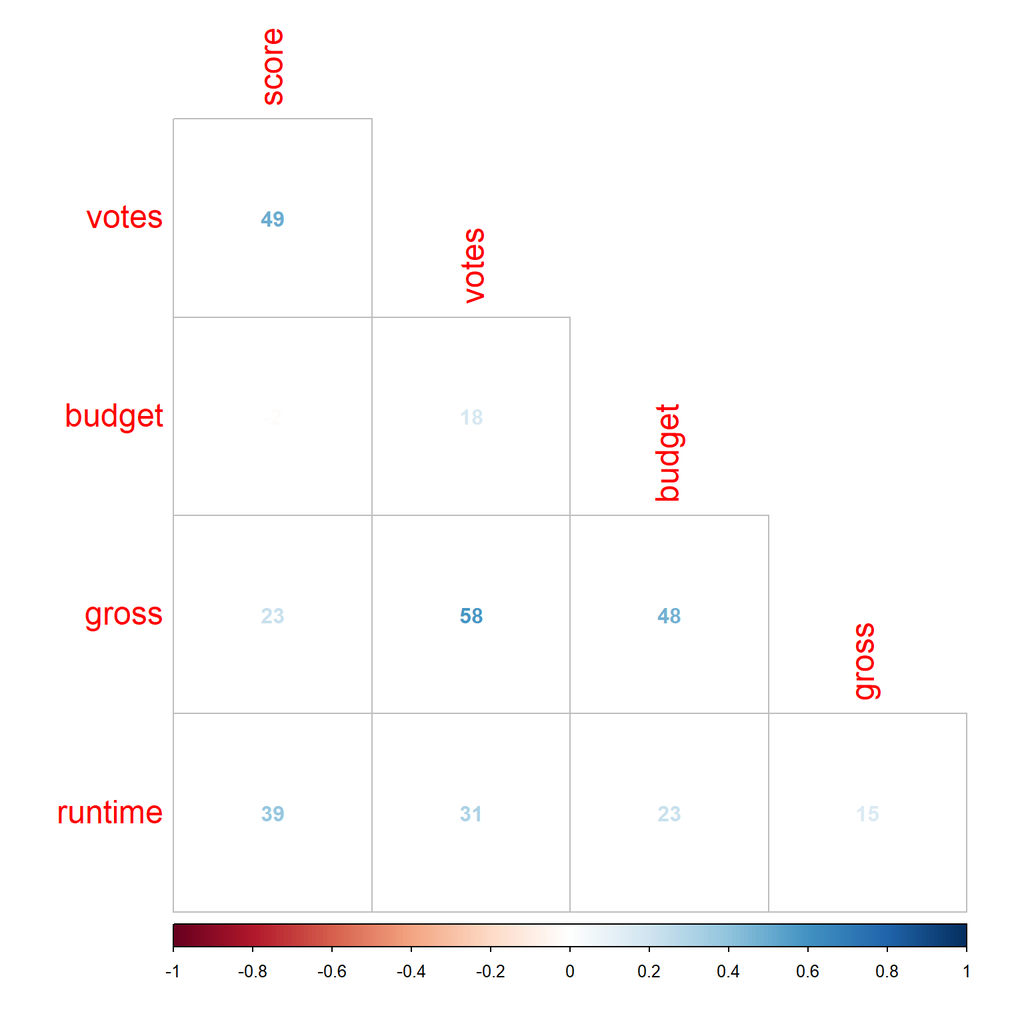

```r
df.num <- df %>%
          na.omit() %>%
          select(-year) %>%
          select_if(is.numeric)
corrplot(corr = cor(df.num), method = "number", diag = FALSE, type = "lower", addCoefasPercent = TRUE, tl.cex = 1.5)
```

# Clustering

## Data preparation

In order to compute clustering, gower distance was chosen due to the fact that in our dataset we have both numerical and categorical data.

```r
#creating dummy column if more than 50 values are belongign to the same country.
df_country<- df %>%
          group_by(country) %>%
          summarise(counts = n())

if(max(df_country$counts) > 50){
          df['country_dummy'] <- ifelse(df$country == df_country$country[df_country$counts == max(df_country$counts)], TRUE, FALSE)
}
```

```r
if('country_dummy' %in% colnames(df)){
          df_cluster = df %>%
          select(rating, genre, score, budget, gross, runtime, country_dummy)
}else{
      df_cluster = df %>%
          select(rating, genre, score, budget, gross, runtime, country)
}
```

```r
df_cluster1 <- daisy(df_cluster, metric = "gower")
summary(df_cluster1)
```

```
## 13041 dissimilarities, summarized :
##     Min.  1st Qu.   Median     Mean  3rd Qu.     Max.
## 0.007319 0.237010 0.350060 0.340040 0.428680 0.743180
## Metric :  mixed ;  Types = N, N, I, I, I, I, A
## Number of objects : 162
```

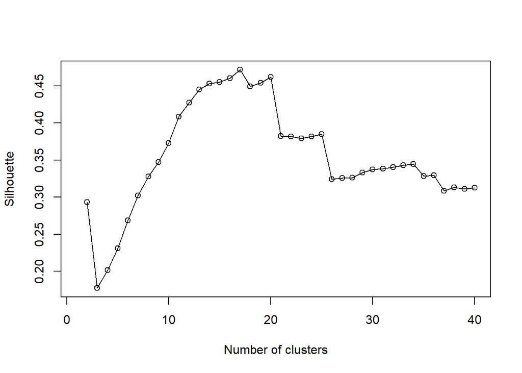

```
## [1] 17
```

```r
silhouette <- c()
k_num <- 1:40

for(i in k_num){

  pam <- pam(as.matrix(df_cluster1),
             diss = TRUE,
             k = i)

  silhouette[i] <- pam$silinfo$avg.width

}

plot(1:40,
     silhouette,
     xlab = "Number of clusters",
     ylab = "Silhouette")

lines(1:40,  silhouette)
```

Based on the silhouette width information we can say that optimal number of clusters using gower method is 17

# Visualization of clusters

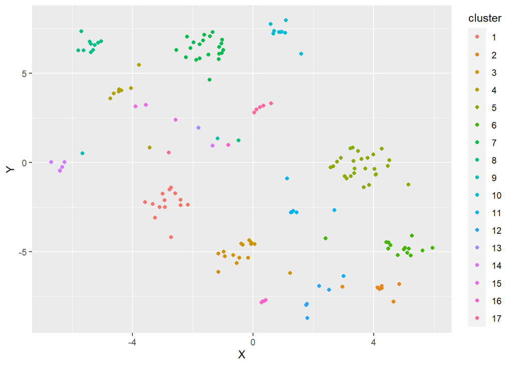

```r
pam_fit <- pam(df_cluster1, diss = TRUE, k = max_k)
tsne <- Rtsne(df_cluster1, is_distance = TRUE)

tsne_info <- tsne$Y %>%
  data.frame() %>%
  setNames(c("X", "Y")) %>%
  mutate(cluster = factor(pam_fit$clustering))

ggplot(aes(x = X, y = Y), data = tsne_info) +
  geom_point(aes(color = cluster))
```

# CONCLUSION